# Afazje

Agata Zywert

## Afazje

### **Klasyfikacja afazji według Łurii**

U Łurii podstawowym pojęciem jest idea **układu funkcjonalnego.** Czynność realizowana jest przez grupę współpracujących ze sobą struktur, z których każda realizuje jakiś aspekt danej funkcji. Tworzą one **układ funkcjonalny**. Również czynności mowy ralizowane są przez układ funkcjonalny. Zawiera on **6 głównych czynników**, uszkodzenie każdego z nich daje odmienne objawy afatyczne.

##### **Afazja dynamiczna**

1. **Czynnik**: Mowa wewnętrzna - możliwość tworzenia wypowiedzi rozwiniętych
2. **Lokalizacja**: Przednia część zakrętu czołowego
3. **Deficyt**: Niemożność tworzenia wypowiedzi, trudności syntaktyczne

##### **Afazja akustyczno-mnestyczna**

1. **Czynnik**: Słuchowa pamięć słowna - zdolność do podtrzymywania w pamięci słuchowych wzorców słów
2. **Lokalizacja**: Środkowy i dolny zakręt skroniowy
3. **Deficyt**: Zmniejszenie pojemnośći bufora słuchowej pamięci werbalnej

##### **Afazja akustyczno-gnostyczna**

1. **Czynnik**: Słuch fonematyczny - analiza i synteza dźwięków mowy
2. **Lokalizacja**: okolice Wernickiego
3. **Deficyt**: Niemożność różnicowania i rozpoznawania dźwięków mowy(neologizmy, parafazje)

##### **Afazja eferentna motoryczna**

1. **Czynnik**: sekwencyjna organizaca ruchów narządów artykulacyjnych, płynne wykonywanie ciągów ruchu
2. **Lokalizacja**: ok. Broca
3. **Deficyt**: Mylenie kolejności wzorców motorycznych, parafazje, zaburzenia sekwencji organizacji ruchów

##### **Afazja aferentna motoryczna**

1. **Czynnik**: analiza i synteza doznań czuciowych z narządów jamy ustnej
2. **Lokalizacja**: wieczko ciemieniowe
3. **Deficyt**: Chory nie wie w jakim ułożeniu są jego narządu artykulacyjne

##### **Afazja semantyczna**

1. **Czynnik**: synteza symultatywna, warunek ujmowania związków logiczno-gramatycznych między słowami
2. **Lokalizacja**: styk ciemieniowo - skroniowo - potyliczny
3. **Deficyt**: Brak rozumienia relacji między słowami, mylenie konstrukcji oznaczających relacje przestrzenne, przynależność etc.

### **Klasyfikacja bostońska**

#### **Afazje niepłynne**:

##### **Afazja Broca (ruchowa)**

1. **zaburzone**: nazywanie, powtarzanie, wypowiedzi pisemne, trudności w czytaniu ze zrozumieniem
2. **zachowane**: rozumienie
3. **lokalizacja**: tylna część zakrętu czołowego dolnego (okolice Broca)
4. **wypowiedzi**: ubogie, krótkie, agramatyczne

##### **Afazja transkorowa ruchowa**

1. **zaburzone**: samodzielne formułowanie wypowiedzi (także pisemnych)
2. **zachowane**: nazywanie (ale często osłabione), rozuemienie, powtarzanie, czytanie ze zrozumieniem
3. **lokalizacja**: Struktury przed i/lub powyżej okolicy Broca i/lub połączenia tych okolic z dodatkowym polem ruchowym
4. **wypowiedzi**: Trudności w samodzielnych formułowaniu i odpowiedziach na pytania otwarte

##### **Afazja mieszana (ruchowo-czuciowa)**

1. **zaburzone**: nazywanie, czytanie ze zrozumieniem, powtarzanie, rozumienie
2. **zachowane**: NIC
3. **lokalizacja**: rozległe uszkodzenie czołowo-skroniowo-ciemieniowe
4. **wypowiedzi**: Zakłócenie wszystkich funkcji językowych

##### **Afazja transkorowa mieszania (*Zespół odizolowania*)**

1. **zaburzone**: nazywanie, rozumienie, czytanie ze zrozumieniem
2. **zachowane**: powtarzanie
3. **lokalizacja**: struktury wokół okolicy Broca i Wernickiego, oddzielenie kluczowych okolic językowych od reszty systemu neuronalnego
4. **wypowiedzi**: Zakłócenie wszystkich funkcji językowych - ubogie wypowiedzi, agramatyczne, perseweracje

#### **Afazaje płynne**

##### **Afazja Wernickiego (czuciowa)**

1. **zaburzone**: nazywanie, czytanie ze zrozumieniem, powtarzanie, rozumienie
2. **zachowane**: płynność wypowiedzi
3. **lokalizacja**: tylna część zakrętu skroniowego górnego (ok. Wernickiego)
4. **wypowiedzi**: Rozbudowane, ale niepoprawnie brzmieniowo i treściowo (parafazje, neologizmy)

##### **Afazja kondukcyjna (przewodzenia)**

1. **zaburzone**: nazywanie, powtarzanie (mocno), wypowiedzi pisemne, czytanie ze zrozumieniem
2. **zachowane**: rozumienie (ale może być osłabione)
3. **lokalizacja**: rejon zakrętu nadbrzeżnego i/lub biegnących pod nim dróg istoty białej (m.in pęczka łukowatego)
4. **wypowiedzi**: Ograniczone przez zniekształcenia słów (parafazje fonemiczne), echolalia

##### **Afazja transkorowa czuciowa**

1. **zaburzone**: nazywanie, czytanie ze zrozumieniem, rozumienie (osłabione), wypowiedzi pisemne
2. **zachowane**: powtarzanie
3. **lokalizacja**: okolice styku skroniowo - cimieniowo - potylicznego (z oszczędzeniem ok. Wernickiego)
4. **wypowiedzi**: Rozbudowane, ale z parafazjami, błędnym doborem słów

##### **Afazja anomiczna (amnestyczna)**

1. **zaburzone**: nazywanie
2. **zachowane**: rozumienie, powtarzanie, wyp. pisemne, czytanie ze zrozumieniem
3. **lokalizacja**: tylny obszar skroniowo - ciemieniowy
4. **wypowiedzi**: Trudnośći w akualizacji słóW

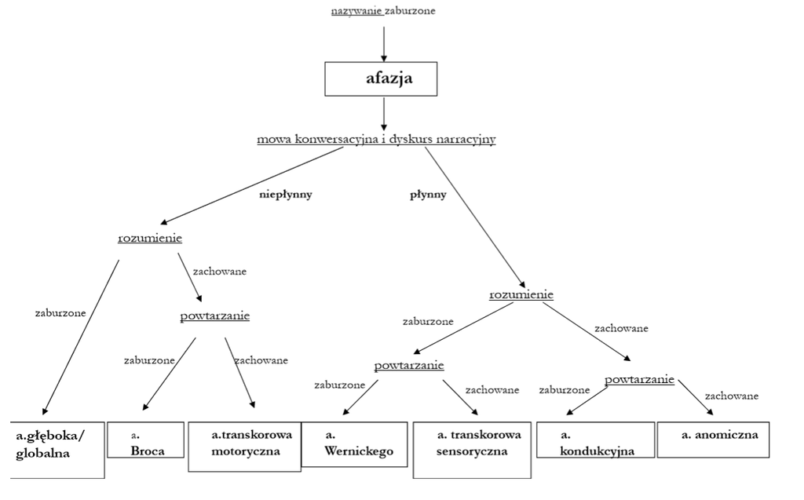

### Charakterystyka i różnice w afazjach płynnych i niepłynnych

| Afazje niepłynne | Afazje płynne |
| --- | --- |
| przeciętna liczba słów na jednostkę czasu niższa od przedchorobowej, częste przerwy między wypowiedziami | przeciętna liczba słów na jednostkę czasu równa przedchorobowej, czasem ją przewyższa |
| artykulacja zaburzona, wyraźny wysiłek | nie ma zaburzeń artykulacji |
| prozodia zwykle zaburzona | łatwo rozróżnić zdania przeczące, twierdzące, pytające etc. |
| długość frazy poniżej 4 słów | długość frazy wynosi 5 - 8 słów |
| Występuje agramatyzm (brak lub redukcja form gramatycznych) | Paragramatyzmy (nieprawidłowe zastosowanie zasad gramatycznych) |
| W mowie dominują czasowniki i rzeczowniki w formie podstawowej, występują trudności w wiązaniu ich w zdania | Dominują stereotypowe zwroty nie niosące znaczenia, trudne do odnalezienia słowa zastępowane są omówieniami, w mowie brak znaczących semantycznie czasowników i rzeczowników |
| Parafazje wynikające z transpozycji słów, sylab i głosek | Parafazje werbalne i głoskowe (zamiast poprawnych słów, głosek i sylab pojawiają się błędne - niekiedy podobne dźwiękowo czy znaczeniowo) |
| Spada częstość użycia funktorów określających relacje słów i zdań | Obecne są funktory (przyimki i spójniki) określające relacje słów i zdań (niekiedy błędnie użyte) |
| W skrajnym nasileniu pojawia się tzw. „styl telegraficzny”, czyli wypowiadanie wyłącznie pojedynczych słów znaczących w formie podstawowej. | W skrajnym nasileniu -tzw. „żargon” - przy zachowaniu cech prozodycznych, mowa jest bezsensownym ciągiem sylab i neologizmów |
| Częste perseweracje | Perseweracje są rzadkie |
| Uszkodzenie mózgu dotyczy przedśrodkowych struktur obszaru mowy | Uszkodzenie mózgu dotyczy zaśrodkowych struktur obszaru mowy |